# problem_15

Codes used to type and visualise the answers can be found [here](https://github.com/Satriawidy/ortvay_2026)

**Question**

The Hamiltonian of a mechanical system with one degree of freedom is the following:

\begin{equation*} H(q, p) = A\frac{\tan(\alpha p^2 + \beta q^2)}{(\alpha p^2 + \beta q^2)^{12}} \end{equation*} where $A, \alpha$, and $\beta$ are real parameters.

Derive the canonical equations of motion and solve them analytically. Sketch the phase space of the system, plot the trajectories. Find the fixpoints and study their stability. Discuss the solutions according to the values of the parameters.

(Gyula Dávid)

**Answer**

The canonical equations of motion is the Hamilton equation. To help make the calculation more efficient, let us define $x = \alpha p^2 + \beta q^2$, leading to $H = A\tan(x)/x^{12}$. We will then obtain

\begin{align*} \dot{p} &= -\frac{\partial H}{\partial q} = -\frac{\partial H}{\partial x}\frac{\partial x}{\partial q} = -2\beta qH'\\ \dot{q} &= \frac{\partial H}{\partial p} = \frac{\partial H}{\partial x}\frac{\partial x}{\partial p} = 2\alpha pH' \end{align*} where \begin{equation*} H' = A\left[\frac{\sec^2(x)}{x^{12}} - 12\frac{\tan(x)}{x^{13}}\right] \end{equation*}

**Is it a circle?**

Given an initial $p_0, q_0$, we might ask, what kind of trajectory will $p$ and $q$ trace? Suppose we move in time by an infinitesimal time $dt$. Moving from $p, q \equiv p(t), q(t)$ to $p',q' \equiv p(t+dt), q(t+dt)$, we would have

\begin{align*} p' &= p - 2\beta qH'~dt\\ q' &= q + 2\alpha pH'~dt\\ \alpha p'^2 + \beta q'^2 &= \alpha[p^2 - 2\beta pqH'~dt + \mathcal{O}(dt^2) ] + \beta[q^2 - 2\alpha pqH'~dt + \mathcal{O}(dt^2)]\\ &= \alpha p^2 + \beta q^2 + \mathcal{O}(dt^2) \end{align*}

Starting from $p_0, q_0$, we can 'induce' that $p$ and $q$ will satisfy \begin{equation*} \alpha p^2 + \beta q^2 = \alpha p_0^2 + \beta q_0^2 \end{equation*} which could be a circle $(\alpha = \beta)$, an ellips $(\alpha^2 \neq \alpha * \beta > 0)$, or a hyperbole. We can also show this property by writing

\begin{align*} \ddot{q} &= 2\alpha \left[\dot{p}H' + 2pH''(\alpha p\dot{p} + \beta q\dot{q})\right]\\ \ddot{q}&= 2\alpha \left[\dot{p}H' + 2pH''(-2\alpha\beta pqH' + 2\alpha\beta pqH')\right]\\ \ddot{q}&= -4\alpha\beta (H')^2q\\ \ddot{p}&= -4\alpha\beta (H')^2p \end{align*} where the last line can be straightforwardly obtained by repeating the previous calculations. These are two other versions of the equation of motions, where now we can see much more clearly the oscillating behaviour that happens when $\alpha\beta > 0$ and exponential behaviour when $\alpha\beta < 0$.

**Phase space**

Let us try visualize the phase space. The phase space will generally depends on the value of $\alpha, \beta$, following the previous discussions. Here we illustrate the phase space, with the color representing ranges of the absolute value of $H/A$.

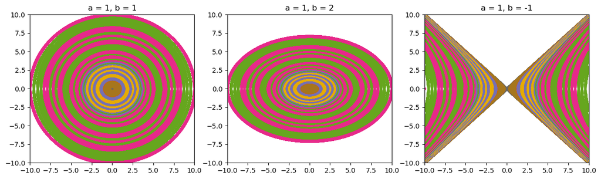

```python
import numpy as np
import matplotlib as mpl
import matplotlib.pyplot as plt

cmap = mpl.colormaps['Dark2']
clrs = cmap(np.linspace(0, 1, 1001))
xs = np.arange(-10, 10, 0.001)
Xs = np.logspace(-2, 2, 100)
Hs = np.tan(Xs)/(Xs**12)
Hl = np.log(np.abs(Hs))
Hn = np.astype(500 * (Hl - Hl.min()) / (Hl.max() - Hl.min()), np.int64)
Hn = Hn * np.astype((Hs/np.abs(Hs)), np.int64) + 500
As = [1, 1, 1]
Bs = [1, 2,-1]

fig, axes = plt.subplots(nrows = 1, ncols = 3, figsize = (15, 4))

for i, ab in enumerate(zip(As, Bs)):
    a, b = ab
    for X, H in zip(Xs, Hn):
        y2 = (X - a*(xs**2)) / b
        axes[i].scatter(xs[y2 >= 0], np.sqrt(y2[y2 >= 0]),
                        color = clrs[H], marker = '.')
        axes[i].scatter(xs[y2 >= 0],-np.sqrt(y2[y2 >= 0]),
                        color = clrs[H], marker = '.')
    axes[i].set_title(f'a = {a}, b = {b}')
for ax in axes:
    ax.set_xlim(-10, 10)
    ax.set_ylim(-10, 10)
plt.show()
```

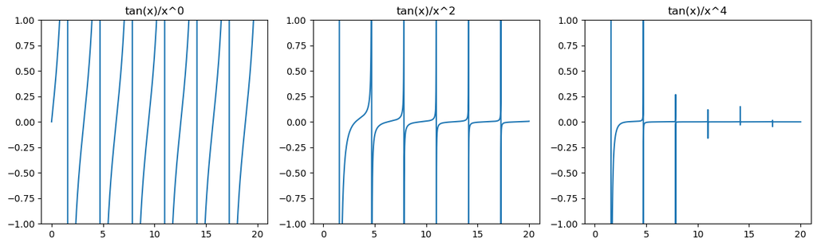

```python
# Showing the periodicity of tan(x)/x^n for different value of n

fig, axes = plt.subplots(nrows = 1, ncols = 3, figsize = (15, 4))
Xs = np.arange(0.001, 20.01, 0.001)
ns = np.array([0, 2, 4])
for n, ax in zip(ns, axes):
    ax.plot(Xs, np.tan(Xs)/(Xs**n))
    ax.set_ylim(-1, 1)
    ax.set_title(f'tan(x)/x^{n}')
plt.show()
```

**Fixed points**

Can we have fixed points here? The fixed points appear when $H' = 0$ (It can technically appear for $\{p, q\} = \{0, 0\}$, but let's not talk about it), which is satisfied by

\begin{equation*} x\sec^2(x) - 12\tan(x) = 0 \end{equation*}

We can plot this function and notice the fixed points as the points where the line intersect zero.

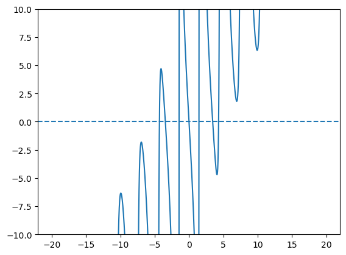

```python
Xs = np.arange(-20.0, 20.01, 0.01)
plt.plot(Xs, Xs / (np.cos(Xs)**2) - 12 * np.tan(Xs))
plt.axhline(0, linestyle = 'dashed')
plt.ylim(-10, 10)
plt.show()
```

We have found seven fixed points (or trajectory, as this represent $x$ instead of $p, q$) for each set of parameters. Now, what is the stability condition for these fixed points? One way to test it is by computing the eigenvalue of the Jacobian $J$, where $J$ is

\begin{equation*} J = \begin{pmatrix} \frac{\partial \dot{p}}{\partial p}& \frac{\partial \dot{p}}{\partial q}\\ \frac{\partial \dot{q}}{\partial p}& \frac{\partial \dot{q}}{\partial q} \end{pmatrix} \end{equation*}

All negative eigenvalues would indicate stability, while the existence of one positive eigenvalues indicate instability. In our case, the eigenvalue equation gives

\begin{align*} 0 &= \left[\lambda - \frac{\partial \dot{p}}{\partial p}\right]\left[\lambda - \frac{\partial \dot{q}}{\partial q}\right] - \frac{\partial \dot{p}}{\partial q}\frac{\partial \dot{q}}{\partial p}\\ 0 &= \left[\lambda + 4\alpha\beta pq H''\right]\left[\lambda - 4\alpha\beta pq H''\right] - \left[-2\beta H' - 4\beta^2q^2H''\right]\left[2\alpha H' + 4\alpha^2p^2H''\right] \end{align*} we know that in the fixed points, $H' = 0$, so we get \begin{align*} 0 &= \lambda^2 - 16\alpha^2\beta^2 p^2q^2 (H'')^2 + 16\alpha^2\beta^2 p^2q^2 (H'')^2\\ 0 &= \lambda^2 \end{align*} which indicate that we could not know the stability using the standard analysis.